# Data Preparation

Bernd Funovits

17 July 2021

# Data Source

For comparison and replication purposes, we use the same data source as Gouriéroux et al. (2019) (see, https://academic.oup.com/restud/advance-article/doi/10.1093/restud/rdz028/5490841#supplementary-data). The raw data is obtained from https://econpapers.repec.org/software/bocbocode/rtz00017.htm (“RATS program to replicate Blanchard and Quah AER 1989”, including an excel file with quarterly data which is described below). For convenience, we saved the raw data as csv file and import it below.

```r
bq_data = read_delim("../local_data/g_gmr_bq/bqdata.csv",
                     delim = ";",
                     escape_double = FALSE,
                     col_types = cols(DATE = col_date(format = "%Y-%m-%d")),
                     trim_ws = TRUE)
```

The column names are

```r
bq_data %>% names()
```

```
## [1] "DATE"  "GNP"   "GD87"  "LHMUR"
```

```r
bq_data %>% head()
```

| DATE | GNP | GD87 | LHMUR |
| --- | --- | --- | --- |
| 1948-01-01 | 252.4000 | 19.5576 | 3.133333 |
| 1948-04-01 | 259.7000 | 19.8105 | 3.200000 |
| 1948-07-01 | 266.6001 | 20.1477 | 3.133333 |
| 1948-10-01 | 267.8999 | 20.0634 | 3.366667 |
| 1949-01-01 | 262.7000 | 19.8948 | 4.200000 |
| 1949-04-01 | 259.2000 | 19.7262 | 5.300000 |

```r
bq_data %>% tail()
```

| DATE | GNP | GD87 | LHMUR |
| --- | --- | --- | --- |
| 1986-07-01 | 4300.000 | 97.2 | 6.200000 |
| 1986-10-01 | 4340.500 | 98.0 | 6.100000 |
| 1987-01-01 | 4412.398 | 98.8 | 5.800000 |
| 1987-04-01 | 4497.500 | 99.5 | 5.566667 |
| 1987-07-01 | 4577.699 | 100.3 | 5.266667 |
| 1987-10-01 | 4690.500 | 101.2 | 5.000000 |

Plot the raw data:

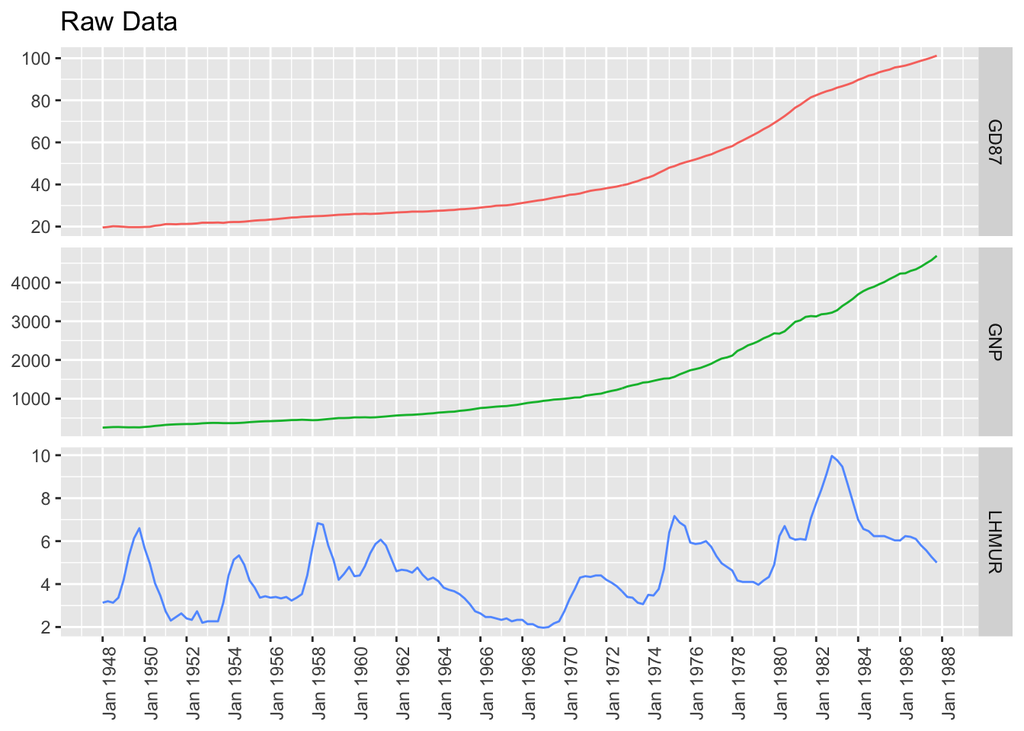

```r
if(params$MAKE_PLOTS){

  bq_data_gg = bq_data %>%
    pivot_longer(-DATE, names_to = "Variable", values_to = "Value")

  bq_data_gg %>%
    ggplot(aes(DATE, Value, color = Variable)) +
    geom_line() +
    facet_grid(Variable ~ ., scales = "free_y") +
    scale_x_date(date_labels = "%b %Y", date_breaks = "2 years") +
    theme(legend.position = "none",
          axis.text.x = element_text(angle = 90),
          axis.title.x = element_blank(),
          axis.title.y = element_blank()) +
    ggtitle("Raw Data")
}
```

# Data Transformations

We use the same transformations as Gouriéroux et al. (2019), which are in line with what is described in Blanchard and Quah (1989, page 661). First, we transform the raw data to obtain real GDP and its (quarterly) change.

```r
bq_data = bq_data %>%
  rename(Unemployment = LHMUR) %>%
  mutate(realGDP = GNP/GD87) %>%
  select(-GNP, -GD87) %>%
  mutate(lag_realGDP = dplyr::lag(realGDP)) %>%
  mutate(rGDPgrowth = (realGDP - lag_realGDP)/lag_realGDP) %>%
  select(-lag_realGDP)
```

```r
bq_data %>% head()
```

| DATE | Unemployment | realGDP | rGDPgrowth |
| --- | --- | --- | --- |
| 1948-01-01 | 3.133333 | 12.90547 | NA |
| 1948-04-01 | 3.200000 | 13.10921 | 0.015787219 |
| 1948-07-01 | 3.133333 | 13.23228 | 0.009388424 |
| 1948-10-01 | 3.366667 | 13.35267 | 0.009097683 |
| 1949-01-01 | 4.200000 | 13.20446 | -0.011099825 |
| 1949-04-01 | 5.300000 | 13.13989 | -0.004890047 |

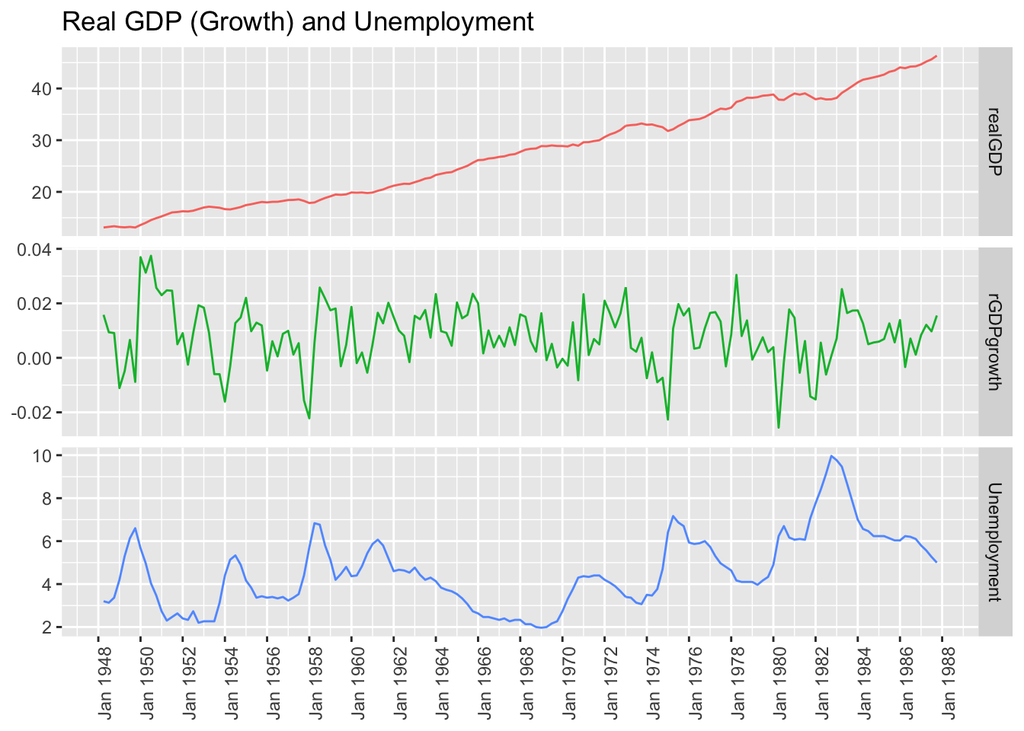

```r
if(params$MAKE_PLOTS){

  bq_data_gg = bq_data %>%
    drop_na() %>%
    pivot_longer(-DATE, names_to = "Variable", values_to = "Value")

  bq_data_gg %>%
    ggplot(aes(DATE, Value, color = Variable)) +
    geom_line() +
    facet_grid(Variable ~ ., scales = "free_y") +
    scale_x_date(date_labels = "%b %Y", date_breaks = "2 years") +
    theme(legend.position = "none",
          axis.text.x = element_text(angle = 90),
          axis.title.x = element_blank(),
          axis.title.y = element_blank()) +
    ggtitle("Real GDP (Growth) and Unemployment")
}
```

Second, we divide the data into two regimes because of different average growth rates of real GDP (equivalently to Gouriéroux et al. (2019) and as described in Blanchard and Quah (1989)). The first period is from 1948Q1 to 1973Q4, the second one from 1974Q1 to 1987Q4.

```r
bq_data = bq_data %>%
  mutate(regime = c(rep(1, 104), rep(2, nrow(bq_data)-104))) %>%
  group_by(regime) %>%
  select(-realGDP) %>%
  mutate(realGDPgrowth = 100*rGDPgrowth) %>%
  mutate(realGDPgrowth_mean = mean(realGDPgrowth, na.rm = TRUE)) %>%
  ungroup()
```

Last, we detrend the unemployment rate.

```r
bq_data = bq_data %>%
  mutate(linear_time_trend = 1:nrow(bq_data))

lm_unemp = lm(Unemployment ~ linear_time_trend, data = bq_data)
```

```r
bq_data = bq_data %>%
  mutate(realGDPgrowth_demeaned = realGDPgrowth - realGDPgrowth_mean) %>%
  mutate(Unemployment_trend = lm_unemp$fitted.values) %>%
  mutate(Unemployment_detrended = Unemployment - lm_unemp$fitted.values)
```

# Plot Transformed Data

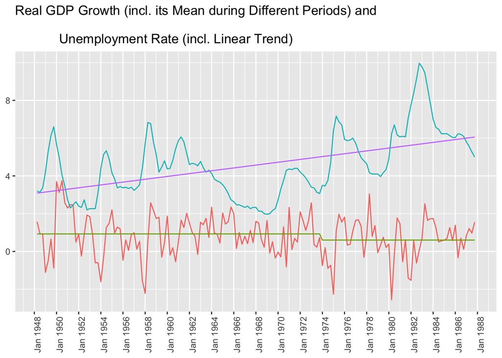

```r
if(params$MAKE_PLOTS){
  bq_data %>%
    select(DATE, realGDPgrowth, realGDPgrowth_mean, Unemployment, Unemployment_trend) %>%
    drop_na() %>%
    pivot_longer(-DATE, names_to = "Variable", values_to = "Value") %>%
    ggplot(aes(DATE, Value, color = Variable)) + geom_line() +
    scale_x_date(date_labels = "%b %Y", date_breaks = "2 years") +
    theme(legend.position = "none",
          axis.text.x = element_text(angle = 90),
          axis.title.x = element_blank(),
          axis.title.y = element_blank()) +
    ggtitle("Real GDP Growth (incl. its Mean during Different Periods) and\n
            Unemployment Rate (incl. Linear Trend)")
}
```

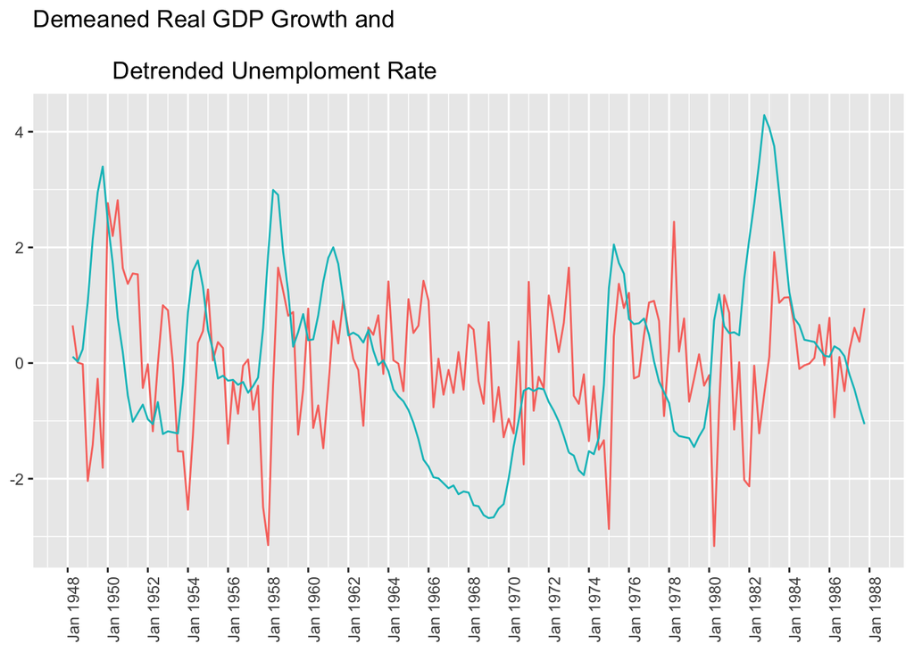

```r
if(params$MAKE_PLOTS){
  bq_data %>%
    select(DATE, realGDPgrowth_demeaned, Unemployment_detrended) %>%
    drop_na() %>%
    pivot_longer(-DATE, names_to = "Variable", values_to = "Value") %>%
    ggplot(aes(DATE, Value, color = Variable)) + geom_line() +
    scale_x_date(date_labels = "%b %Y", date_breaks = "2 years") +
    theme(legend.position = "none",
          axis.text.x = element_text(angle = 90),
          axis.title.x = element_blank(),
          axis.title.y = element_blank()) +
    ggtitle("Demeaned Real GDP Growth and \n
            Detrended Unemploment Rate")
}
```

# Save Data as rds-Objects

Finally, we save the data as matrix object and xts object.

```r
bq_data = bq_data %>%
  select(DATE, realGDPgrowth_demeaned, Unemployment_detrended) %>%
  drop_na()

data_mat = bq_data %>%
  select(-DATE) %>%
  as.matrix()

data_xts = xts(data_mat, order.by = bq_data$DATE)

if(!file.exists("../local_data/g_gmr_bq/data_mat.rds")){
  saveRDS(data_mat, "../local_data/g_gmr_bq/data_mat.rds")
}

if(!file.exists("../local_data/g_gmr_bq/data_xts.rds")){
  saveRDS(data_xts, "../local_data/g_gmr_bq/data_xts.rds")
}
```

# Comparison with McCracken and Ng data

```r
unemp_xts = quantmod::getSymbols.FRED("LNS14000025", auto.assign = FALSE)
## Registered S3 method overwritten by 'quantmod':
##   method            from
##   as.zoo.data.frame zoo
unemp_xts["1948/1987",]
```

```
##            LNS14000025
## 1948-01-01         3.0
## 1948-02-01         3.1
## 1948-03-01         3.3
## 1948-04-01         3.4
## 1948-05-01         3.2
## 1948-06-01         3.0
## 1948-07-01         2.9
## 1948-08-01         3.2
## 1948-09-01         3.3
## 1948-10-01         3.3
## 1948-11-01         3.3
## 1948-12-01         3.5
## 1949-01-01         3.8
## 1949-02-01         4.2
## 1949-03-01         4.6
## 1949-04-01         4.7
## 1949-05-01         5.5
## 1949-06-01         5.7
## 1949-07-01         6.2
## 1949-08-01         6.2
## 1949-09-01         6.0
## 1949-10-01         7.9
## 1949-11-01         6.0
## 1949-12-01         5.9
## 1950-01-01         5.7
## 1950-02-01         5.6
## 1950-03-01         5.7
## 1950-04-01         5.4
## 1950-05-01         4.9
## 1950-06-01         4.6
## 1950-07-01         4.4
## 1950-08-01         3.9
## 1950-09-01         3.8
## 1950-10-01         3.5
## 1950-11-01         3.4
## 1950-12-01         3.5
## 1951-01-01         3.0
## 1951-02-01         2.7
## 1951-03-01         2.5
```

[output cut: 426 more lines]

```
## 1986-10-01         6.2
## 1986-11-01         6.1
## 1986-12-01         6.0
## 1987-01-01         5.9
## 1987-02-01         5.8
## 1987-03-01         5.7
## 1987-04-01         5.5
## 1987-05-01         5.6
## 1987-06-01         5.6
## 1987-07-01         5.4
## 1987-08-01         5.3
## 1987-09-01         5.1
## 1987-10-01         5.1
## 1987-11-01         5.0
## 1987-12-01         4.9
```

```r
unemp_t = unemp_xts %>% as_tibble() %>%
  add_column(date = index(unemp_xts))

unemp_t = unemp_t %>%
  filter(year(date) >= 1948,year(date) <= 1987) %>%
  rename(unemp = LNS14000025)
```

```r
rGDP = quantmod::getSymbols.FRED("GDPC1", auto.assign = FALSE)
rGDP_t = rGDP %>% as_tibble() %>%
  add_column(date = index(rGDP))

rGDP_t = rGDP_t %>%
  filter(year(date) >= 1948, year(date) <= 1987) %>%
  left_join(unemp_t)
## Joining, by = "date"
```

```r
fred_data = rGDP_t %>%
  mutate(r_gdp_growth = (GDPC1 - dplyr::lag(GDPC1))/dplyr::lag(GDPC1)) %>%
  select(date, r_gdp_growth, unemp)
```

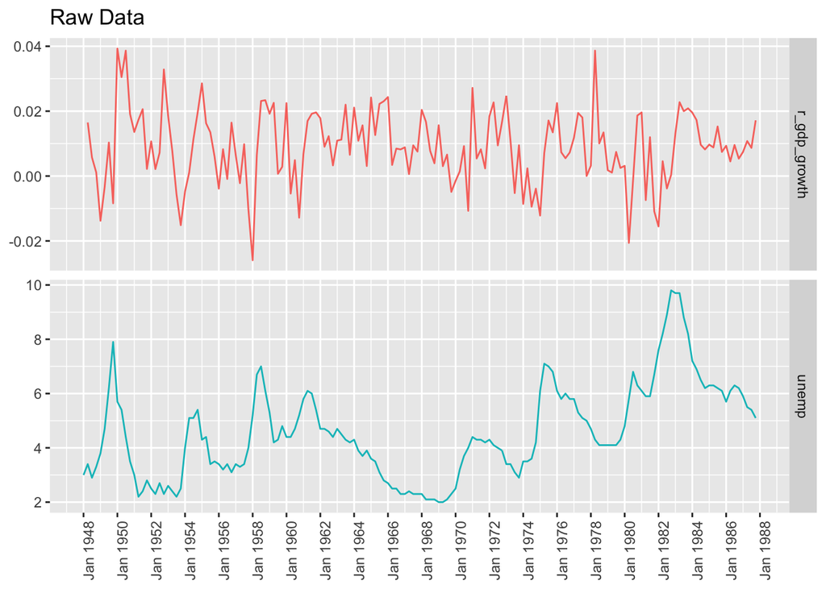

```r
fred_data %>%
  pivot_longer(-date) %>%
  ggplot(aes(x=date, y= value, colour = name)) +
  geom_line() +
  facet_grid(name ~ ., scales = "free_y") +
    scale_x_date(date_labels = "%b %Y", date_breaks = "2 years") +
    theme(legend.position = "none",
          axis.text.x = element_text(angle = 90),
          axis.title.x = element_blank(),
          axis.title.y = element_blank()) +
    ggtitle("Raw Data")
```